# Practical Machine Learning Course Assignment Writeup

Yiannis Niflis

27 / 02 / 2016

The training data for this project are available here: https://d396qusza40orc.cloudfront.net/predmachlearn/pml-training.csv

The test data are available here: https://d396qusza40orc.cloudfront.net/predmachlearn/pml-testing.csv

Import caret package and read the files and import them in your working directory, also replace all missing values with NA (in order to delete them later):

```r
library(caret)
library(randomForest)
library(e1071)
library(rpart) # Regressive Partitioning and Regression trees
```

```r
library(rpart.plot) # Decision Tree plot
url1 <- "http://d396qusza40orc.cloudfront.net/predmachlearn/pml-training.csv"
download.file(url1, destfile="pmltraining.csv")
url2 <- "http://d396qusza40orc.cloudfront.net/predmachlearn/pml-testing.csv"
download.file(url2, destfile="pmltesting.csv")
training_raw <- read.csv("pmltraining.csv", header=TRUE, na.strings=c("NA","#DIV/0!", ""))
testing_raw <- read.csv("pmltesting.csv", header=TRUE, na.strings=c("NA","#DIV/0!", ""))
```

I keep those variables which are related to sensors (e.g. belt, arm, dumbbell, forearm) and the classe variable as it holds the classification of the activity performed by the user.

Also I discard the variables which have only null values and irrelevant variables with our project.

```r
sensor_col <- grepl("belt|arm|dumbbell|forearm|classe",names(training_raw))
training_set <- training_raw[,sensor_col]
null_col <- colSums(is.na(training_set))!=0
training_set <- training_set[,!null_col]
training_set   <-training_set[,-c(1:7)]
```

Example of scaterplots we could create to check relationships between variables

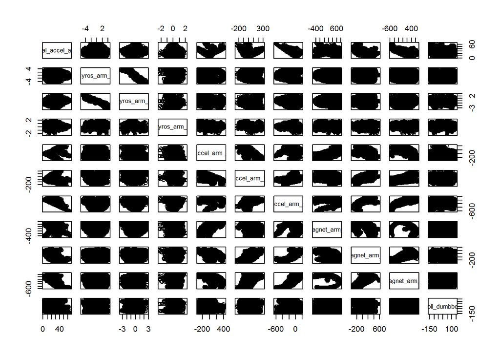

```r
pairs(training_set[1:10000,10:20])
```

Split of the original training set into two subsets (train 80% and testing 20%) and then use train then creating the model

```r
set.seed(1234)
training_cv_index <- createDataPartition(training_set$classe,list=FALSE ,p=0.8)
training_cv <- training_set[training_cv_index,]
validation_cv <- training_set[-training_cv_index,]
```

Creating a Prediction model using desicion trees

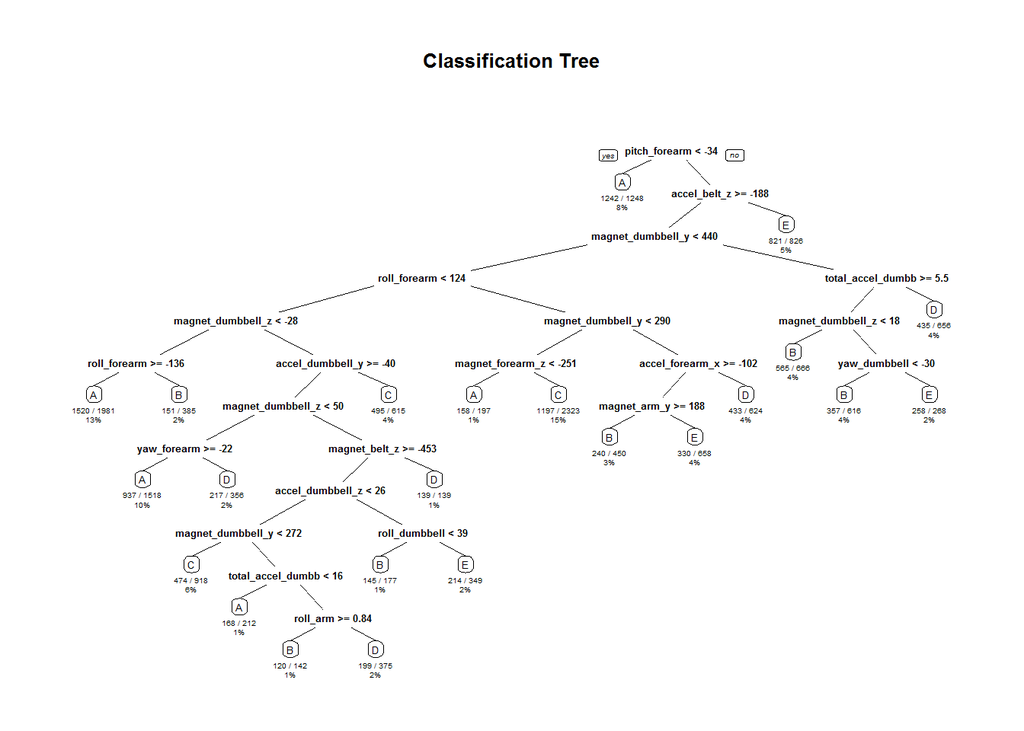

```r
model <- rpart(classe ~ ., data=training_cv, method="class")
# Predicting:
prediction1 <- predict(model, validation_cv, type = "class")
# Plot of the Decision Tree
rpart.plot(model, main="Classification Tree", extra=102, under=TRUE, faclen=0)
```

see the results of the model

```r
model
```

```
## n= 15699
##
## node), split, n, loss, yval, (yprob)
##       * denotes terminal node
##
##    1) root 15699 11235 A (0.28 0.19 0.17 0.16 0.18)
##      2) pitch_forearm< -33.95 1248     6 A (1 0.0048 0 0 0) *
##      3) pitch_forearm>=-33.95 14451 11229 A (0.22 0.21 0.19 0.18 0.2)
##        6) accel_belt_z>=-187.5 13625 10407 A (0.24 0.22 0.2 0.19 0.15)
##         12) magnet_dumbbell_y< 439.5 11419  8262 A (0.28 0.18 0.23 0.18 0.13)
##           24) roll_forearm< 123.5 7167  4347 A (0.39 0.18 0.18 0.16 0.093)
##             48) magnet_dumbbell_z< -27.5 2366   808 A (0.66 0.2 0.012 0.078 0.048)
##               96) roll_forearm>=-136.5 1981   461 A (0.77 0.17 0.013 0.028 0.025) *
##               97) roll_forearm< -136.5 385   234 B (0.099 0.39 0.0078 0.34 0.17) *
##             49) magnet_dumbbell_z>=-27.5 4801  3539 A (0.26 0.16 0.26 0.2 0.11)
##               98) accel_dumbbell_y>=-40.5 4186  2929 A (0.3 0.18 0.18 0.23 0.11)
##                196) magnet_dumbbell_z< 49.5 1874   937 A (0.5 0.096 0.12 0.22 0.071)
##                  392) yaw_forearm>=-22.15 1518   581 A (0.62 0.084 0.12 0.13 0.055) *
##                  393) yaw_forearm< -22.15 356   139 D (0 0.15 0.1 0.61 0.14) *
##                197) magnet_dumbbell_z>=49.5 2312  1736 B (0.14 0.25 0.23 0.24 0.15)
##                  394) magnet_belt_z>=-453 2173  1597 B (0.15 0.27 0.24 0.19 0.16)
##                    788) accel_dumbbell_z< 25.5 1647  1130 C (0.18 0.25 0.31 0.19 0.069)
##                     1576) magnet_dumbbell_y< 271.5 918   444 C (0.13 0.22 0.52 0.11 0.026) *
##                     1577) magnet_dumbbell_y>=271.5 729   520 B (0.25 0.29 0.059 0.28 0.12)
##                       3154) total_accel_dumbbell< 16.5 212    44 A (0.79 0.12 0.014 0.033 0.038) *
##                       3155) total_accel_dumbbell>=16.5 517   318 D (0.027 0.35 0.077 0.38 0.16)
##                         6310) roll_arm>=0.845 142    22 B (0.042 0.85 0.11 0 0) *
##                         6311) roll_arm< 0.845 375   176 D (0.021 0.17 0.064 0.53 0.22) *
##                    789) accel_dumbbell_z>=25.5 526   293 E (0.03 0.32 0.0076 0.2 0.44)
##                     1578) roll_dumbbell< 38.61985 177    32 B (0.023 0.82 0.023 0.028 0.11) *
##                     1579) roll_dumbbell>=38.61985 349   135 E (0.034 0.069 0 0.28 0.61) *
##                  395) magnet_belt_z< -453 139     0 D (0 0 0 1 0) *
##               99) accel_dumbbell_y< -40.5 615   120 C (0.0081 0.041 0.8 0.029 0.12) *
##           25) roll_forearm>=123.5 4252  2861 C (0.079 0.18 0.33 0.22 0.19)
##             50) magnet_dumbbell_y< 290.5 2520  1323 C (0.094 0.14 0.47 0.14 0.15)
##              100) magnet_forearm_z< -251 197    39 A (0.8 0.071 0 0.051 0.076) *
##              101) magnet_forearm_z>=-251 2323  1126 C (0.034 0.14 0.52 0.15 0.16) *
##             51) magnet_dumbbell_y>=290.5 1732  1143 D (0.058 0.24 0.11 0.34 0.25)
##              102) accel_forearm_x>=-101.5 1108   724 E (0.051 0.3 0.16 0.14 0.35)
##                204) magnet_arm_y>=188.5 450   210 B (0.013 0.53 0.23 0.1 0.12) *
##                205) magnet_arm_y< 188.5 658   328 E (0.078 0.14 0.11 0.17 0.5) *
##              103) accel_forearm_x< -101.5 624   191 D (0.069 0.12 0.027 0.69 0.087) *
##         13) magnet_dumbbell_y>=439.5 2206  1191 B (0.028 0.46 0.039 0.21 0.26)
##           26) total_accel_dumbbell>=5.5 1550   619 B (0.039 0.6 0.054 0.02 0.29)
##             52) magnet_dumbbell_z< 17.5 666   101 B (0.092 0.85 0 0.014 0.047) *
##             53) magnet_dumbbell_z>=17.5 884   471 E (0 0.41 0.094 0.025 0.47)
##              106) yaw_dumbbell< -30.4869 616   259 B (0 0.58 0.13 0.036 0.25) *
##              107) yaw_dumbbell>=-30.4869 268    10 E (0 0.034 0.0037 0 0.96) *
##           27) total_accel_dumbbell< 5.5 656   221 D (0 0.13 0.003 0.66 0.21) *
##        7) accel_belt_z< -187.5 826     5 E (0.0048 0.0012 0 0 0.99) *
```

Model Validation

```r
confusionMatrix(prediction1, validation_cv$classe)
```

```
## Confusion Matrix and Statistics
##
##           Reference
## Prediction    A    B    C    D    E
##          A 1003  143   62   66   56
##          B   37  398   61   50   84
##          C   48  113  520  125  110
##          D    9   69   23  345   75
##          E   19   36   18   57  396
##
## Overall Statistics
##
##                Accuracy : 0.6786
##                  95% CI : (0.6637, 0.6932)
##     No Information Rate : 0.2845
##     P-Value [Acc > NIR] : < 2.2e-16
##
##                   Kappa : 0.5907
##  Mcnemar's Test P-Value : < 2.2e-16
##
## Statistics by Class:
##
##                      Class: A Class: B Class: C Class: D Class: E
## Sensitivity            0.8987   0.5244   0.7602  0.53655   0.5492
## Specificity            0.8835   0.9267   0.8777  0.94634   0.9594
## Pos Pred Value         0.7541   0.6317   0.5677  0.66219   0.7529
## Neg Pred Value         0.9564   0.8904   0.9455  0.91240   0.9043
## Prevalence             0.2845   0.1935   0.1744  0.16391   0.1838
## Detection Rate         0.2557   0.1015   0.1326  0.08794   0.1009
## Detection Prevalence   0.3390   0.1606   0.2335  0.13281   0.1341
## Balanced Accuracy      0.8911   0.7255   0.8190  0.74144   0.7543
```

predict model values

```r
resultfull <-predict(model,testing_raw)
result <-predict(model,testing_raw,type ="class")
resultfull
```

```
##             A           B           C          D          E
## 1  0.03400775 0.141627206 0.515281963 0.15066724 0.15841584
## 2  0.76728925 0.166582534 0.013124685 0.02776376 0.02523978
## 3  0.01333333 0.533333333 0.231111111 0.10222222 0.12000000
## 4  0.13289760 0.215686275 0.516339869 0.10893246 0.02614379
## 5  0.13289760 0.215686275 0.516339869 0.10893246 0.02614379
## 6  0.03400775 0.141627206 0.515281963 0.15066724 0.15841584
## 7  0.06891026 0.123397436 0.027243590 0.69391026 0.08653846
## 8  0.02133333 0.168000000 0.064000000 0.53066667 0.21600000
## 9  0.99519231 0.004807692 0.000000000 0.00000000 0.00000000
## 10 0.76728925 0.166582534 0.013124685 0.02776376 0.02523978
## 11 0.03400775 0.141627206 0.515281963 0.15066724 0.15841584
## 12 0.01333333 0.533333333 0.231111111 0.10222222 0.12000000
## 13 0.03400775 0.141627206 0.515281963 0.15066724 0.15841584
## 14 0.99519231 0.004807692 0.000000000 0.00000000 0.00000000
## 15 0.07750760 0.142857143 0.110942249 0.16717325 0.50151976
## 16 0.03438395 0.068767908 0.000000000 0.28366762 0.61318052
## 17 0.61725955 0.083662714 0.119235837 0.12516469 0.05467721
## 18 0.09870130 0.392207792 0.007792208 0.33506494 0.16623377
## 19 0.09870130 0.392207792 0.007792208 0.33506494 0.16623377
## 20 0.01333333 0.533333333 0.231111111 0.10222222 0.12000000
```

```r
result
```

```
##  1  2  3  4  5  6  7  8  9 10 11 12 13 14 15 16 17 18 19 20
##  C  A  B  C  C  C  D  D  A  A  C  B  C  A  E  E  A  B  B  B
## Levels: A B C D E
```

second prediction

Creating a Prediction model using random forests, rest of the code is the same

```r
model2 <- randomForest(classe ~. , data=training_cv, method="class")

# Predicting:
prediction2 <- predict(model2, validation_cv, type = "class")
```

see the results of the model

```r
model2
```

```
##
## Call:
##  randomForest(formula = classe ~ ., data = training_cv, method = "class")
##                Type of random forest: classification
##                      Number of trees: 500
## No. of variables tried at each split: 6
##
##         OOB estimate of  error rate: 0.89%
## Confusion matrix:
##      A    B    C    D    E class.error
## A 4458    5    0    0    1 0.001344086
## B   23 3008    6    1    0 0.009874918
## C    0   26 2708    4    0 0.010956903
## D    0    0   59 2509    5 0.024873688
## E    0    3    2    4 2877 0.003118503
```

Model Validation

```r
confusionMatrix(prediction2, validation_cv$classe)
```

```
## Confusion Matrix and Statistics
##
##           Reference
## Prediction    A    B    C    D    E
##          A 1116    4    0    0    0
##          B    0  752    7    0    2
##          C    0    3  677   15    0
##          D    0    0    0  628    0
##          E    0    0    0    0  719
##
## Overall Statistics
##
##                Accuracy : 0.9921
##                  95% CI : (0.9888, 0.9946)
##     No Information Rate : 0.2845
##     P-Value [Acc > NIR] : < 2.2e-16
##
##                   Kappa : 0.99
##  Mcnemar's Test P-Value : NA
##
## Statistics by Class:
##
##                      Class: A Class: B Class: C Class: D Class: E
## Sensitivity            1.0000   0.9908   0.9898   0.9767   0.9972
## Specificity            0.9986   0.9972   0.9944   1.0000   1.0000
## Pos Pred Value         0.9964   0.9882   0.9741   1.0000   1.0000
## Neg Pred Value         1.0000   0.9978   0.9978   0.9954   0.9994
## Prevalence             0.2845   0.1935   0.1744   0.1639   0.1838
## Detection Rate         0.2845   0.1917   0.1726   0.1601   0.1833
## Detection Prevalence   0.2855   0.1940   0.1772   0.1601   0.1833
## Balanced Accuracy      0.9993   0.9940   0.9921   0.9883   0.9986
```

predict model values

```r
resultfull2 <-predict(model2,testing_raw)
result2 <-predict(model2,testing_raw,type ="class")
resultfull2
```

```
##  1  2  3  4  5  6  7  8  9 10 11 12 13 14 15 16 17 18 19 20
##  B  A  B  A  A  E  D  B  A  A  B  C  B  A  E  E  A  B  B  B
## Levels: A B C D E
```

```r
result2
```

```
##  1  2  3  4  5  6  7  8  9 10 11 12 13 14 15 16 17 18 19 20
##  B  A  B  A  A  E  D  B  A  A  B  C  B  A  E  E  A  B  B  B
## Levels: A B C D E
```

I select the random forest prediction due to better performance in confusion matrix and statistics